# startR 3: Tableaux de données

Lise Vaudor

21 mars 2017

# Lecture de tables: Répertoire de travail

Le **répertoire de travail** (**w**orking **d**irectory) est le **dossier de votre ordinateur où, sauf précision de votre part, R lit et écrit les fichiers**.

Vous pouvez afficher le répertoire de travail de la manière suivante:

```r
getwd()
```

```
## [1] "C:/Users/lvaudor/Desktop/FORMATIONS/INITIATION/startR"
```

Vous pouvez changer de répertoire de travail avec la commande `setwd()`:

```r
setwd("../../GRAPHIQUES_GGPLOT2/")
getwd()
```

```
## [1] "C:/Users/lvaudor/Desktop/FORMATIONS/GRAPHIQUES_GGPLOT2"
```

Remarquez que le chemin est écrit **avec des `/` et non avec des `\`**

Vous pouvez également utiliser les **fonctionnalités de RStudio** pour changer de répertoire de travail.

[figure not shown]

# Lecture de tables: Fonction read.table()

Examinons la commande suivante:

```r
air <- read.table(file="datasets/air.txt",
                  sep=",",
                  dec=".",
                  header=T)
air[1:3,]  # 3 premieres lignes du tableau
```

```
##   Ozone Solar.R Wind Temp Month Day
## 1    41     190  7.4   67     5   1
## 2    36     118  8.0   72     5   2
## 3    12     149 12.6   74     5   3
```

La fonction read.table() permet de **lire** la table contenue dans le **fichier “air.txt”** qui se trouve dans le dossier “datasets” du répertoire de travail.

Le chemin vers le fichier est ici indiqué de manière **relative** c’est-à-dire qu’on indique comment trouver “air.txt” depuis le répertoire de travail actuel.

Le chemin peut aussi être indiquée de manière **absolue**, en indiquant le chemin complet depuis la racine:

```r
air <- read.table(file="C:/Users/lvaudor/Desktop/FORMATIONS/INITIATION/startR/datasets/air.txt",
                  sep=",",
                  dec=".",
                  header=T)
```

# Lecture de tables: Fonction read.table()

Examinons la commande suivante:

```r
air <- read.table(file="datasets/air.txt",
                  sep=",",
                  dec=".",
                  header=T)
air[1:3,]  # 3 premieres lignes du tableau
```

```
##   Ozone Solar.R Wind Temp Month Day
## 1    41     190  7.4   67     5   1
## 2    36     118  8.0   72     5   2
## 3    12     149 12.6   74     5   3
```

Il existe de **nombreux arguments** à cette fonction, qui sont détaillés dans le fichier d’aide associé.

Outre l’argument **file** qui permet d’indiquer le chemin du fichier à lire, voici quelques uns des arguments les plus importants:

- le **séparateur de colonnes** : par ex. une virgule (`sep=","`), un point-virgule (`sep=";"`), une tabulation? (`sep="\tab"`), etc.
- le **séparateur décimal** (`dec=","` ou `sep="."` )
- la présence d’un **header** i.e. le fait que la première ligne du tableau corresponde aux noms des variables (`header=TRUE`) ou non (`header=FALSE`)

# Lecture de tables: Nettoyer ses données!

Attention, utilisateurs de tableurs, cette diapo est pour vous…

Si vous avez des difficultés à lire votre tableau des données, c’est sans doute parce que celui-ci n’est pas un tableau de données **brutes**.

Pour lire un tableau de données sous R, il convient d’abord de **nettoyer ce tableau**:

- Vérifier que les noms de colonnes ne contiennent pas de **caractères spéciaux ou des espaces**, avoir des noms de variables **courts** mais **explicites**
- Vérifier si certains champs correspondent en fait à des **commentaires**, si votre tableur contient des **graphiques**, etc..

[figure not shown]

Ceci n’est pas de la donnée brute!

# Lecture de tables: en passant par RStudio

[figure not shown]

[figure not shown]

# Lecture de tables: attacher/détacher

Pour accéder à une des variables d’un tableau il faut a priori utiliser le système d’indexation (`table$variable`).

On peut également **attacher** le tableau de données à l’environnement R pour ne pas avoir à taper le nom du tableau sans arrêt:

```r
attach(air)
Ozone[1:40]
```

```
##  [1]  41  36  12  18  NA  28  23  19   8  NA   7  16  11  14  18  14  34
## [18]   6  30  11   1  11   4  32  NA  NA  NA  23  45 115  37  NA  NA  NA
## [35]  NA  NA  NA  29  NA  71
```

A l’inverse, on peut redétacher une table de la manière suivante:

```r
detach(air)
Ozone[1:40]
```

```
## Error in eval(expr, envir, enclos): objet 'Ozone' introuvable
```

# Ecriture de tables: Fonction write.table()

A l’inverse, il est possible d’écrire des fichiers depuis R. Pour écrire une table, par exemple:

```r
t1
```

```
##    Espece      Nom Date
## 1   Chien   Lassie 1940
## 2 Dauphin  Flipper 1964
## 3    Chat Garfield 1978
## 4  Eponge      Bob 1999
```

```r
write.table(t1,
            "table_animaux_stars.csv",
            sep=";",
            col.names=TRUE,
            row.names=FALSE)
```

Cette-fois les arguments principaux sont:

- **x**: l’objet table à écrire
- **file**: le nom de fichier de votre choix (ou chemin, si vous ne souhaitez pas écrire le fichier dans le répertoire de travail)
- **sep**: le séparateur de colonnes
- **col.names**: pour écrire les noms de colonnes (par défaut: TRUE)
- **row.names**: pour écrire les noms de lignes (par défaut: TRUE).

# Structure et dimensions d’une table

```r
str(air) # structure du tableau
```

```
## 'data.frame':    153 obs. of  6 variables:
##  $ Ozone  : int  41 36 12 18 NA 28 23 19 8 NA ...
##  $ Solar.R: int  190 118 149 313 NA NA 299 99 19 194 ...
##  $ Wind   : num  7.4 8 12.6 11.5 14.3 14.9 8.6 13.8 20.1 8.6 ...
##  $ Temp   : int  67 72 74 62 56 66 65 59 61 69 ...
##  $ Month  : int  5 5 5 5 5 5 5 5 5 5 ...
##  $ Day    : int  1 2 3 4 5 6 7 8 9 10 ...
```

```r
colnames(air) # nom des colonnes
```

```
## [1] "Ozone"   "Solar.R" "Wind"    "Temp"    "Month"   "Day"
```

```r
dim(air) # dimensions
```

```
## [1] 153   6
```

```r
length(air$Ozone) # longueur du vecteur
```

```
## [1] 153
```

```r
nrow(air) # nombre de lignes
```

```
## [1] 153
```

```r
ncol(air) #nombre de colonnes
```

```
## [1] 6
```

Pour afficher les **premières lignes** du tableau:

```r
head(air)
```

```
##   Ozone Solar.R Wind Temp Month Day
## 1    41     190  7.4   67     5   1
## 2    36     118  8.0   72     5   2
## 3    12     149 12.6   74     5   3
## 4    18     313 11.5   62     5   4
## 5    NA      NA 14.3   56     5   5
## 6    28      NA 14.9   66     5   6
```

Pour afficher les **dernières lignes** du tableau:

```r
tail(air)
```

```
##     Ozone Solar.R Wind Temp Month Day
## 148    14      20 16.6   63     9  25
## 149    30     193  6.9   70     9  26
## 150    NA     145 13.2   77     9  27
## 151    14     191 14.3   75     9  28
## 152    18     131  8.0   76     9  29
## 153    20     223 11.5   68     9  30
```

# RStudio view data

[figure not shown]

```r
require(dplyr)
```

# dplyr: Introduction()

**dplyr** est un package qui permet de faire simplement diverses opérations sur les tableaux de données:

- `select()` permet de **sélectionner des variables** (colonnes)
- `filter()` permet de **filtrer les individus** (lignes)
- `arrange()` permet de **réarranger le tableau selon l’ordre des variables**
- `mutate()` permet de **créer et ajouter de nouvelles variables** (colonnes)
- `summarise()` permet de **résumer plusieurs valeurs en une seule**

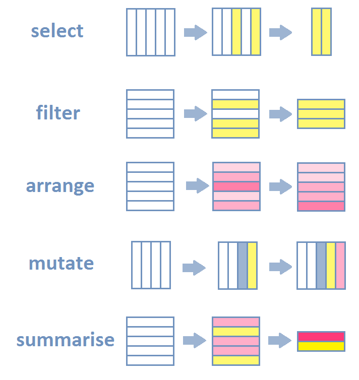

# dplyr: select()

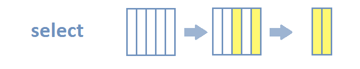

**select()** permet de **sélectionner des variables**

Par exemple, on peut sélectionner des variables de la table `air`

```r
head(air)
```

```
##   Ozone Solar.R Wind Temp Month Day
## 1    41     190  7.4   67     5   1
## 2    36     118  8.0   72     5   2
## 3    12     149 12.6   74     5   3
## 4    18     313 11.5   62     5   4
## 5    NA      NA 14.3   56     5   5
## 6    28      NA 14.9   66     5   6
```

- en spécifiant les **noms** ou **numéros** des variables à **conserver**

```r
data <- select(air,Ozone,Wind,Temp)
data[1:2,]
```

```
##   Ozone Wind Temp
## 1    41  7.4   67
## 2    36  8.0   72
```

```r
data <- select(air, 1,3,4)
data[1:2,]
```

```
##   Ozone Wind Temp
## 1    41  7.4   67
## 2    36  8.0   72
```

- en spécifiant le **nom** ou les **numéros** des variables à **écarter** avec le signe **-**

```r
data <- select(air,-Month,-Day)
data[1:2,]
```

```
##   Ozone Solar.R Wind Temp
## 1    41     190  7.4   67
## 2    36     118  8.0   72
```

# dplyr: select()

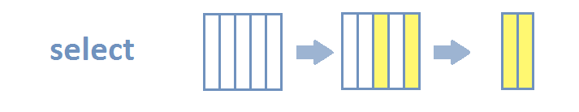

**select()** permet de **sélectionner des variables** en passant par des **fonctions auxiliaires**. On peut citer par exemple:

- `starts_with` pour les variables qui **commencent** par un texte donné
- `ends_with` pour les variables qui **terminent** par un texte donné
- `contains` pour les variables qui **contiennent** un texte donné
- etc.

Par exemple:

```r
head(dat_tmp)
```

```
##             X        Y  conc_Fe  conc_Mg  conc_Pb
## 1 -0.07099923 2.981014 2.279312 7.855522 3.673563
## 2  5.53051093 3.417561 2.836930 7.487139 3.582564
## 3  2.52848430 3.567788 2.847776 7.408360 3.206137
## 4  3.54875843 5.139947 2.817021 6.557268 2.733517
## 5  2.33102726 4.312889 2.914908 6.815215 3.330579
## 6  4.74918214 4.428560 2.320642 7.603692 3.180317
```

```r
data <- select(dat_tmp,starts_with("conc"))
head(data)
```

```
##    conc_Fe  conc_Mg  conc_Pb
## 1 2.279312 7.855522 3.673563
## 2 2.836930 7.487139 3.582564
## 3 2.847776 7.408360 3.206137
## 4 2.817021 6.557268 2.733517
## 5 2.914908 6.815215 3.330579
## 6 2.320642 7.603692 3.180317
```

# dplyr: filter()

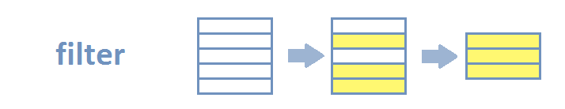

**filter()** permet de **filtrer les lignes du tableau** en fonction des valeurs de telle ou telle variable.

Ici, par exemple, on cherche toutes les lignes qui correspondent au mois de juillet:

```r
data <- filter(air,Month==7)
nrow(data)
```

```
## [1] 31
```

```r
head(data)
```

```
##   Ozone Solar.R Wind Temp Month Day
## 1   135     269  4.1   84     7   1
## 2    49     248  9.2   85     7   2
## 3    32     236  9.2   81     7   3
## 4    NA     101 10.9   84     7   4
## 5    64     175  4.6   83     7   5
## 6    40     314 10.9   83     7   6
```

On peut **combiner plusieurs conditions logiques** (ET logique, par une virgule ou un &, OU logique, par l’opérateur |).

Par exemple,

- pour ne conserver que les lignes qui telles que Ozone>100 **et** Wind>5:

```r
data <- filter(air, Ozone>100, Wind>5)
data
```

```
##   Ozone Solar.R Wind Temp Month Day
## 1   115     223  5.7   79     5  30
## 2   108     223  8.0   85     7  25
## 3   110     207  8.0   90     8   9
```

- pour ne conserver que les lignes telles que Month==7 **ou** Month==8:

```r
data <- filter(air, Month==7|Month==8)
nrow(data)
```

```
## [1] 62
```

# dplyr: arrange()

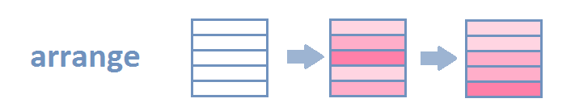

Pour réarranger un tableau selon l’ordre d’une variable, on peut faire appel à la fonction `arrange` (ici, par exemple on réordonne `air` selon l’ordre croissant de `Temp` et `Wind`):

```r
data <- arrange(air,Temp, Wind)
head(data)
```

```
##   Ozone Solar.R Wind Temp Month Day
## 1    NA      NA 14.3   56     5   5
## 2    NA      NA  8.0   57     5  27
## 3    NA      66 16.6   57     5  25
## 4     6      78 18.4   57     5  18
## 5    18      65 13.2   58     5  15
## 6    NA     266 14.9   58     5  26
```

et pour ordonner par ordre décroissant, on utilise* **desc()**:

```r
data <- arrange(air,desc(Temp))
head(data)
```

```
##   Ozone Solar.R Wind Temp Month Day
## 1    76     203  9.7   97     8  28
## 2    84     237  6.3   96     8  30
## 3   118     225  2.3   94     8  29
## 4    85     188  6.3   94     8  31
## 5    NA     259 10.9   93     6  11
## 6    73     183  2.8   93     9   3
```

# dplyr: mutate()

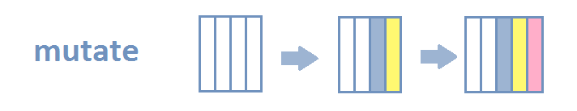

Pour créer de nouvelles variables et les ajouter au tableau de données on peut utiliser la fonction **mutate()**.

Voici par exemple comment procéder si je souhaite créer une nouvelle variable, “Date”, en combinant les variables `Month` et `Day`:

```r
data <- mutate(air,Date=paste(Month,"-",Day,sep=""))
head(data)
```

```
##   Ozone Solar.R Wind Temp Month Day Date
## 1    41     190  7.4   67     5   1  5-1
## 2    36     118  8.0   72     5   2  5-2
## 3    12     149 12.6   74     5   3  5-3
## 4    18     313 11.5   62     5   4  5-4
## 5    NA      NA 14.3   56     5   5  5-5
## 6    28      NA 14.9   66     5   6  5-6
```

- pour transformer les °F en °C:

```r
air=mutate(air,Temp=(Temp-32)/1.8)
head(air)
```

```
##   Ozone Solar.R Wind     Temp Month Day
## 1    41     190  7.4 19.44444     5   1
## 2    36     118  8.0 22.22222     5   2
## 3    12     149 12.6 23.33333     5   3
## 4    18     313 11.5 16.66667     5   4
## 5    NA      NA 14.3 13.33333     5   5
## 6    28      NA 14.9 18.88889     5   6
```

ou si je souhaite calculer des classes de vitesses de vent

```r
data=mutate(air,
            gWind=cut(Wind,breaks=quantile(Wind)))
head(data)
```

```
##   Ozone Solar.R Wind     Temp Month Day       gWind
## 1    41     190  7.4 19.44444     5   1   (1.7,7.4]
## 2    36     118  8.0 22.22222     5   2   (7.4,9.7]
## 3    12     149 12.6 23.33333     5   3 (11.5,20.7]
## 4    18     313 11.5 16.66667     5   4  (9.7,11.5]
## 5    NA      NA 14.3 13.33333     5   5 (11.5,20.7]
## 6    28      NA 14.9 18.88889     5   6 (11.5,20.7]
```

# dplyr: summarise()

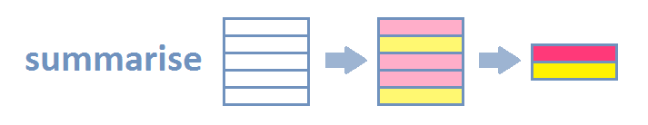

Si l’on souhaite calculer quelques **statistiques** un peu basiques sur un jeu de données, on peut utiliser la fonction **summarise()**.

Par exemple:

```r
data <- summarise(air,
                  mean_Temp=mean(Temp),
                  nb_Mois=n_distinct(Month),
                  nb_Mesures=n())
data
```

```
##   mean_Temp nb_Mois nb_Mesures
## 1   25.4902       5        153
```

Et surtout, si je souhaite calculer une statistique pour **différents groupes** (définis ici, par exemple, par la variable `Month`), je vais le spécifier dans l’argument spécifiant la table de données, à l’aide de **group_by()**:

```r
data <- summarise(group_by(air,Month),
                  mean_Temp=mean(Temp),
                  nb_Mesures=n())
data
```

```
## # A tibble: 5 × 3
##   Month mean_Temp nb_Mesures
##   <int>     <dbl>      <int>
## 1     5  18.63799         31
## 2     6  26.16667         30
## 3     7  28.83513         31
## 4     8  28.87097         31
## 5     9  24.94444         30
```

# dplyr: Chaînage

Vous avez vu que les fonctions de `dplyr` permettaient de faire toutes sortes d’opérations sur les tableaux de données. Il est bien entendu possible de les **combiner** pour réaliser des opérations complexes…

Imaginons par exemple que l’on souhaite répondre à une question telle que

“Quelle est la moyenne de concentration en Ozone pour les 10% de jours les plus chauds de l’année?”

Classiquement, pour coder cette chaîne d’opérations sous R, on procéderait de la manière suivante:

```r
q <- quantile(air$Temp, 0.9)
data1 <- select(air, Ozone, Temp)
data2 <- filter(data1, Temp>=q)
data3 <- summarise(data2, mean_Ozone=mean(Ozone, na.rm=TRUE))
data3
```

```
##   mean_Ozone
## 1   89.61538
```

# dplyr: Chaînage

Si je souhaitais réaliser cet enchaînement de commandes en une seule opération, et ainsi éviter la création d’objets intermédiaires data1, data2, etc., voici (classiquement) comment il faudrait procéder:

```r
q <- quantile(air$Temp, 0.9)
data <- summarise(filter(select(air,
                                Ozone,
                                Temp),
                         Temp>=q),
                   mean_Ozone=mean(Ozone, na.rm=TRUE))
data
```

```
##   mean_Ozone
## 1   89.61538
```

`dplyr` permet d’inverser l’ordre de cette syntaxe en permettant d’utiliser un opérateur (l’opérateur “pipe”) qui s’écrit de la manière suivante : **%>%** et que l’on pourrait (en gros) traduire par **“et puis”**…

Voyez plutôt comment le code ci-dessus peut être simplifié par l’usage de cet opérateur:

```r
q <- quantile(air$Temp, 0.9)
data <- air %>%
  select(Ozone,Temp) %>%
  filter(Temp>=q) %>%
  summarise(mean_Ozone=mean(Ozone,na.rm=TRUE))
data
```

```
##   mean_Ozone
## 1   89.61538
```